# 텍스트분석 뉴스레터: 2023년 8월 전반

sung won kang

2023 8 17

- 한국환경연구원 텍스트 수집 도구는 2023년 8월 15일까지 네이버 기사 데이터와 환경부 문헌 데이터를 제공한다. 아래 뉴스레터에서는 2023년 8월 2일을 기점으로 15일 이전까지 수집한 자료를 사용한다.

### A. Text 데이터

분석 대상 Text Data는 다음 두 종류의 문헌을 자료이다.

1. NAVER 환경 뉴스 : 2023년 8월 2일-2023년 8월 15일 NAVER 뉴스> ‘사회’ >‘환경’ 부문에 게시된 뉴스
2. 환경부 문건 : 2023년 8월 2일-2023년 8월 15일 환경부홈페이지에 게시된 환경부 보도자료 및 e-환경뉴스

’NAVER 환경 뉴스’는 환경정책의 수요자인 국민의 환경과 관련된 관심사를 전달하는 텍스트 자료이다. 그리고 ’환경부 문건’은 환경정책의 공급자인 환경부의 관심사를 전달하는 텍스트 자료이다. 이 두 자료의 키워드를 비교하여 환경정책 공급자의 관심사가 환경정책 수요자의 관심사에 조응하는지 여부를 점검한다.

### B. 키워드 빈도분석

한국환경연구원의 환경 빅데이터 플랫폼에서는 키워드를 단순빈도수 및 TF_IDF 값에 따라 추출한다. 키워드 추출 전단계로 파이선’konlpy’패키지를 활용한 형태소 분석 및 품사 태깅을 수행하고, 불용어(stopwords)를 제거한다. 2023년 8월 2일 - 8월 15일 게시 NAVER 환경뉴스 및 환경부 문건에서 단순빈도수가 높은 20개의 키워드를 추출한 결과는 아래 그림과 같다.

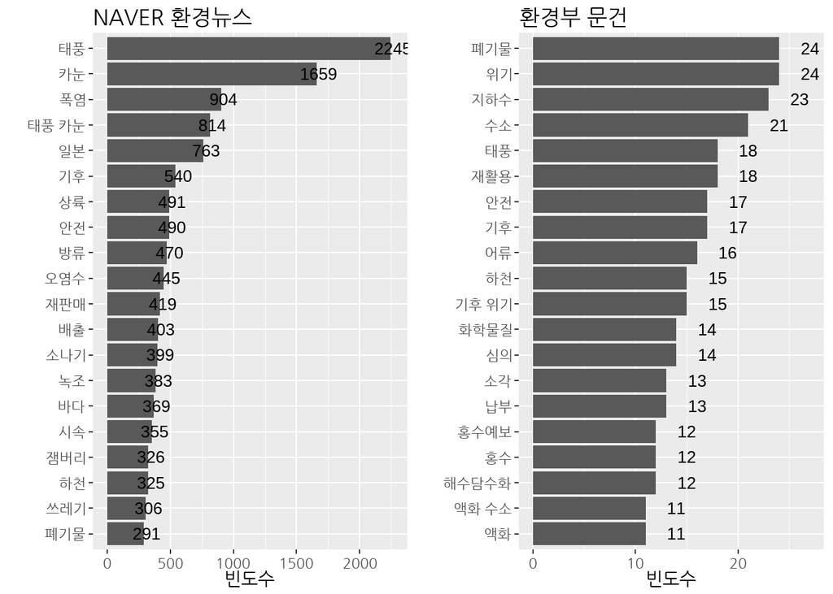

눈에 띄는 특징은 다음과 같이 정리할 수 있다.

- 첫째, 네이버 환경뉴스에는 빈도수가 높은 상위 20개 키워드 중 ‘태풍’,‘카눈’,‘상륙’,‘소나기’,‘방류’,’ 안전’ 등 태풍과 관련된 키워드가 다수 발견되었다. 환경부 문건의 빈도수 상위 20개 키워드 중에도 ‘태풍’,‘안전’,‘홍수예보’,‘홍수’ 등 이에 상응하는 키워드가 다수 발견되었다.
- 둘째, 네이버 환경뉴스에는 빈도수가 높은 상위 20개 키워드 중 ‘오염수’ 가 발견되어 후쿠히마 원전 가동과 관련된 관심이 유지되었음을 시사하였으나, 환경부 문헌에서는 이에 상응하는 키워드가 발견되지 않았다.
- 셋째, 네이버 환경뉴스에는 빈도수가 높은 상위 20개 키워드 중 ‘쓰레기’,‘폐기물’ 이 발견되었으며 환경부 보도자료에도 이에 상응하는 ‘폐기물’,‘재활용’,‘소각’ 과 같은 키워드가 발견되었다.
- 넷째, 환경부 문건의 빈도수 상위 20개 키워드 중에는 ‘수소’,‘액화 수소’ 등 신재생에너지 관련 키워드, ‘해수담수화’,‘지하수’와 같은 수자원 관련 키워드, ’화학물질’ 등 환경정책 관련 키워드가 발견되지만, 네이버 환경뉴스에서는 이에 상응하는 키워드가 발견되지 않았다.

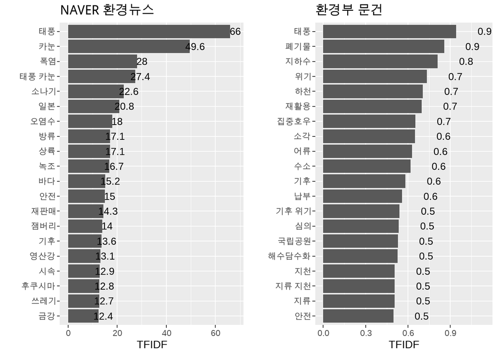

이와 같은 경향은 TF_IDF 값이 높은 20개의 키워드를 추출하여 비교하여도 확인된다. Figure 2는 TF_IDF를 기준으로 추출한 상위 20개 키워드의 TF_IDF 값을 보여준다. Figure 2에서도 확인할 수 있듯이

- ‘오염수’,‘방류’,‘후쿠시마’,’일본’과 같은 키워드는 NAVER 뉴스에서만 찾아볼 수 있다.
- ‘국립공원’과 같이 자연환경과 관련된 키워드, ’지류’,‘지천’과 같이 물환경 관련 키워드,’ 지하수’, ‘해수담수화’ 등 수자원 관련 키워드, ‘지류’,’지천’과 같은 물환경 관련 키워드, ’수소’와 같은 환경정책 관련 키워드는 환경부 문건에서만 찾아 볼 수 있다.
- ‘태풍’, ‘카눈’,‘소나기’,‘상륙’,‘안전’,‘시곡’과 같은 NAVER 뉴스의 키워드와 ’태풍’,‘집중호우’ 와 같은 환경부 문건의 키워드는 태풍에 대한 민간의 관심과 환경부의 관심이 상호 일치함을 보여준다.
- NAVER 뉴스 키워드 ‘쓰레기’와 환경부 문건 키워드 ’폐기물’,’재활용’은 이 시기 폐기물 관련 민간의 관심과 환경부의 관심이 상호 일치함을 보여준다.

### C. 키워드 관련 뉴스

네이버 환경뉴스 키워드와 환경부 문건 키워드간의 차이의 원인을 파악하기 위해서 두 문헌에서 단순빈도가 가장 높은 10개 키워드 중 서로 상이한 키워드가 포함된 문헌의 제목들을 비교하였다.

| Title |
| --- |
| “日 오염수 투기 저지” 광주 주민단체 삭발·단식 |
| 日어민, 원전 장관에 “방류 전인데 수출 안돼…소문피해 대책을” |
| 인천시, 연평도 해역에 참조기 치어 25만마리 방류 |
| 인천시 수산자원연구소, 연평도해역에 어린 참조기 25만마리 방류 |
| “후쿠시마 오염수 우리 해역 영향 미미…해산물 안전” |
| 정부 “오염수 한일 추가 실무협의, 오는 7일 화상으로 개최” |
| 정부 “오염수 한일 추가 실무협의, 오는 7일 화상으로 개최”(종합) |
| 후쿠시마 오염수 해양투기에 국민 소송으로 맞서다 |
| 피지 총리 ‘IAEA 오염수 보고서’ 긍정 평가…日 “깊이 감사” |
| 한일, 이번주 오염수 실무협의… 한미일 정상회담 앞두고 성과 낼까 |

환경부 문헌에서 가장 빈도가 높은 10개 키워드 중 네이버 뉴스에서 가장 빈도가 높은 키워드 20개에 포함되지 않은 키워드는 ‘위기’,‘지하수’,‘수소’,‘재활용’,‘어류’ 이다. 이 중 ‘재활용’은 네이버 뉴스의 키워드 중 ’쓰레기’,’폐기물’에 조응한다. 그리고 ’위기’는 다른 키워드인 ’기후위기’에 포함된 키워드이다. 그 외의 키워드에 조응하는 네이버 뉴스 키워드는 찾아보기 어렵다. 2023년 8월 2일부터 8월 15일까지 게시된 환경부 문헌 중 이들 키워드를 제목에 포함하는 환경부 문헌은 다음과 같다.

1. ’지하수’을 제목에 포함하는 문헌은 1건으로 가상현실로 지하수 관리 체험을 하는 프로그램에 대한 안내 문헌이었다. ’수소’를 제목에 포함하는 문헌은 1건으로 수소버스 보급확대와 관련된 문헌이었다. ’어류’를 제목에 포함하는 문헌은 2건으로 어류 질병 치료와 관련된 연구개발 성과를 소개하는 문헌이었다.

| Title |
| --- |
| 환경부장관, 수소버스 보급 확대에 대비해 액화수소 생산시설 현장 점검 |
| 담수식물 ‘마름’ 추출물에서 어류 출혈성 패혈증 바이러스 억제 효능 발견 |
| 국립호남권생물자원관, 어류 질병 치료 친환경 기술 개발 |
| 가상현실로 청정지하수 관리 체험해요 |

### D. 정리

2023년 8월 2일-2023년 8월 15일 게시된 네이버 환경뉴스와 환경부 문헌을 비교한 결과를 요약하면 다음과 같다.

1. 네이버 기사와 환경부 보도자료 모두 태풍과 관련된 키워드의 출현 빈도가 높았다. 이는 태풍에 대한 국민들의 관심에 환경부의 정책이 시의성있게 대응하였음을 시사한다.
2. 네이버 기사에는 후쿠시마 원전 오염수와 관련된 키워드가 출현하였지만 환경부 문헌에서는 이에 조응하는 키워드가 발견되지 않았다. 이는 2023년 7월까지의 키워드 분석 결과와 일관된 결과이다.